Julien Vieillevigne - DAI - Promo 2024

# I/ The Objectives

#### A) Optimizing responses to filters in a convolutional neural network with an application in the field of facial recognition.

• The usefulness/impact of associating meaning with a filter during knowledge transfer.

• The importance/impact of the number of filters used in each layer.

• The importance/impact of the choice of learning rate during training.

• Identifying problems encountered during the learning phase.

#### B) Testing the validity of statements made in the field of facial recognition and photo anonymization.

• The technique of characterizing classes (Grad-CAM). How a CNN can help us characterize a class.

• The importance/impact of the choice of filter associated with Grad-CAM for proper characterization.

#### C) Compare classification by k-nearest neighbors (kpp) to classification by a neural network.

• The importance/impact of choosing the classification algorithm based on constraints.

#### D) Deploy the trained network in C++ or JavaScript.

• The importance/impact of the library used.

• The constraints and conditions of production (e.g., response time, platform portability).

```python
#pip install tensorflow==2.1.0
#pip install keras==2.3.1
#pip install keras_vggface==0.6
#pip install protobuf==3.20.1
#pip install h5py==2.10.0
#pip install numpy
#pip install pandas
#pip install
```

```python
import pandas as pd
import numpy as np
import matplotlib.pyplot as plt
import tensorflow as tf
import keras
from keras_vggface.vggface import VGGFace
from IPython.display import Image, display
from keras.preprocessing.image import save_img, load_img, img_to_array

model = VGGFace(model='vgg16',include_top=False)
model.summary()
```

```
Model: "vggface_vgg16"
_________________________________________________________________
Layer (type)                 Output Shape              Param #
=================================================================
input_1 (InputLayer)         (None, None, None, 3)     0
_________________________________________________________________
conv1_1 (Conv2D)             (None, None, None, 64)    1792
_________________________________________________________________
conv1_2 (Conv2D)             (None, None, None, 64)    36928
_________________________________________________________________
pool1 (MaxPooling2D)         (None, None, None, 64)    0
_________________________________________________________________
conv2_1 (Conv2D)             (None, None, None, 128)   73856
_________________________________________________________________
conv2_2 (Conv2D)             (None, None, None, 128)   147584
_________________________________________________________________
pool2 (MaxPooling2D)         (None, None, None, 128)   0
_________________________________________________________________
conv3_1 (Conv2D)             (None, None, None, 256)   295168
_________________________________________________________________
conv3_2 (Conv2D)             (None, None, None, 256)   590080
_________________________________________________________________
conv3_3 (Conv2D)             (None, None, None, 256)   590080
_________________________________________________________________
pool3 (MaxPooling2D)         (None, None, None, 256)   0
_________________________________________________________________
conv4_1 (Conv2D)             (None, None, None, 512)   1180160
_________________________________________________________________
conv4_2 (Conv2D)             (None, None, None, 512)   2359808
_________________________________________________________________
conv4_3 (Conv2D)             (None, None, None, 512)   2359808
_________________________________________________________________
pool4 (MaxPooling2D)         (None, None, None, 512)   0
_________________________________________________________________
conv5_1 (Conv2D)             (None, None, None, 512)   2359808
_________________________________________________________________
conv5_2 (Conv2D)             (None, None, None, 512)   2359808
_________________________________________________________________
conv5_3 (Conv2D)             (None, None, None, 512)   2359808
_________________________________________________________________
pool5 (MaxPooling2D)         (None, None, None, 512)   0
=================================================================
Total params: 14,714,688
Trainable params: 14,714,688
Non-trainable params: 0
_________________________________________________________________
```

```python
img_width = 180
img_height = 180
# Our target layer: we will visualize the filters from this layer.
# See `model.summary()` for list of layer names, if you want to change this.
layer_name = "conv1_2"

layer = model.get_layer(name=layer_name)
feature_extractor = keras.Model(inputs=model.inputs, outputs=layer.output)
```

```python
def compute_loss(input_image, filter_index):
    activation = feature_extractor(input_image)
    # We avoid border artifacts by only involving non-border pixels in the loss.
    filter_activation = activation[:, 2:-2, 2:-2, filter_index]
    return tf.reduce_mean(filter_activation)

@tf.function
def gradient_ascent_step(img, filter_index, learning_rate):
    with tf.GradientTape() as tape:
        tape.watch(img)
        loss = compute_loss(img, filter_index)
    # Compute gradients.
    grads = tape.gradient(loss, img)
    # Normalize gradients.
    grads = tf.math.l2_normalize(grads)
    img += learning_rate * grads
    return loss, img

def initialize_image():
    # We start from a gray image with some random noise
    img = tf.random.uniform((1, img_width, img_height, 3))
    # ResNet50V2 expects inputs in the range [-1, +1].
    # Here we scale our random inputs to [-0.125, +0.125]
    return (img - 0.5) * 0.25

def visualize_filter(filter_index):
    # We run gradient ascent for 20 steps
    iterations = 30
    learning_rate = 10.0
    img = initialize_image()
    for iteration in range(iterations):
        loss, img = gradient_ascent_step(img, filter_index, learning_rate)

    # Decode the resulting input image
    img = deprocess_image(img[0].numpy())
    return loss, img


def deprocess_image(img):
    # Normalize array: center on 0., ensure variance is 0.15
    img -= img.mean()
    img /= img.std() + 1e-5
    img *= 0.15

    # Center crop
    img = img[25:-25, 25:-25, :]

    # Clip to [0, 1]
    img += 0.5
    img = np.clip(img, 0, 1)

    # Convert to RGB array
    img *= 255
    img = np.clip(img, 0, 255).astype("uint8")
    return img
```

[output not shown]

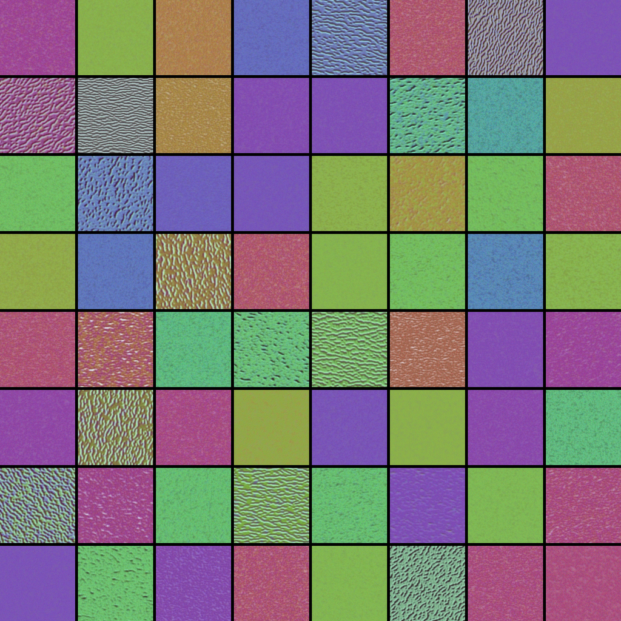

```python
# Compute image inputs that maximize per-filter activations
# for the first 64 filters of our target layer
all_imgs = []
for filter_index in range(64):
    #print("Processing filter %d" % (filter_index,))
    loss, img = visualize_filter(filter_index)
    all_imgs.append(img)

# Build a black picture with enough space for
# our 8 x 8 filters of size 128 x 128, with a 5px margin in between
margin = 5
n = 8
cropped_width = img_width - 25 * 2
cropped_height = img_height - 25 * 2
width = n * cropped_width + (n - 1) * margin
height = n * cropped_height + (n - 1) * margin
stitched_filters = np.zeros((width, height, 3))

# Fill the picture with our saved filters
for i in range(n):
    for j in range(n):
        img = all_imgs[i * n + j]
        stitched_filters[
            (cropped_width + margin) * i : (cropped_width + margin) * i + cropped_width,
            (cropped_height + margin) * j : (cropped_height + margin) * j
            + cropped_height,
            :,
        ] = img
save_img("stiched_filters.png", stitched_filters)


display(Image("stiched_filters.png"))
```

#### B) Testing the validity of statements made in the field of facial recognition and photo anonymization.

• The technique of characterizing classes (Grad-CAM). How a CNN can help us characterize a class.

• The importance/impact of the choice of filter associated with Grad-CAM for proper characterization.

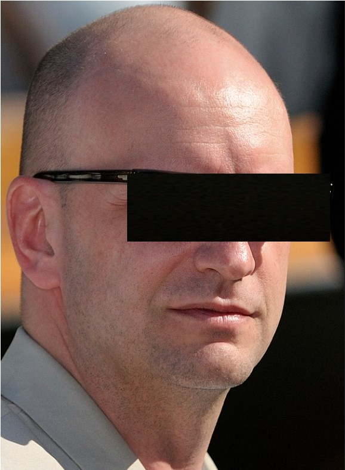

```python
import pandas as pd
import numpy as np
import matplotlib.pyplot as plt
import os
os.environ['CUDA_VISIBLE_DEVICES'] = ''
import tensorflow as tf
import keras
from keras_vggface.vggface import VGGFace
from keras_vggface.utils import decode_predictions, preprocess_input
from IPython.display import Image, display
from keras.preprocessing.image import save_img, load_img, img_to_array, array_to_img
import matplotlib as mpl
from keras import backend as K
from keras.models import Model
from keras.layers import Dense

os.environ["KERAS_BACKEND"] = "tensorflow"

K.clear_session()

# Define the size of the image
img_size = (224, 224)

# Define the last convolutional layer
last_conv_layer_name = "conv5_3"

# The local path to our target image
img_path = r"Steven_Soderbergh_mask.jpg"
display(Image(img_path))
```

```python
def get_img_array(img_path, size):
    img = load_img(img_path, target_size=size)
    # `array` is a float32 Numpy array of shape (299, 299, 3)
    array = img_to_array(img)
    # We add a dimension to transform our array into a "batch"
    # of size (1, 299, 299, 3)
    array = np.expand_dims(array, axis=0)
    return array

def make_gradcam_heatmap(img_array, model, last_conv_layer_name, pred_index=None):
    # First, we create a model that maps the input image to the activations
    # of the last conv layer as well as the output predictions
    grad_model = keras.models.Model(
        model.inputs, [model.get_layer(last_conv_layer_name).output, model.output]
    )

    # Then, we compute the gradient of the top predicted class for our input image
    # with respect to the activations of the last conv layer
    with tf.GradientTape() as tape:
        last_conv_layer_output, preds = grad_model(img_array)
        if pred_index is None:
            pred_index = tf.argmax(preds[0], output_type=tf.int32)
        class_channel = preds[:, pred_index]

    # This is the gradient of the output neuron (top predicted or chosen)
    # with regard to the output feature map of the last conv layer
    grads = tape.gradient(class_channel, last_conv_layer_output,unconnected_gradients='none')

    # This is a vector where each entry is the mean intensity of the gradient
    # over a specific feature map channel
    pooled_grads = tf.reduce_mean(grads, axis=(0, 1, 2))

    # We multiply each channel in the feature map array
    # by "how important this channel is" with regard to the top predicted class
    # then sum all the channels to obtain the heatmap class activation
    last_conv_layer_output = last_conv_layer_output[0]
    heatmap = last_conv_layer_output @ pooled_grads[..., tf.newaxis]
    heatmap = tf.squeeze(heatmap)

    # For visualization purpose, we will also normalize the heatmap between 0 & 1
    heatmap = tf.maximum(heatmap, 0) / tf.math.reduce_max(heatmap)
    return heatmap
```

[output not shown]

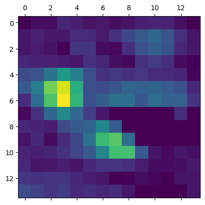

```python
import pydot

with tf.compat.v1.Session() as sess:

    img_array = preprocess_input(get_img_array(img_path, size=img_size))

    # Define the model
    model = VGGFace(model='vgg16', include_top=True)

    # Print what the top predicted class is
    preds = model.predict(img_array)
    pred_class = decode_predictions(preds, top=2611)
    print("Predicted:", decode_predictions(preds, top=353))

    # Generate class activation heatmap
    img_array = tf.convert_to_tensor(img_array)

    heatmap = make_gradcam_heatmap(img_array, model, last_conv_layer_name)
    heatmap_values = sess.run(heatmap)

    # Display heatmap

    plt.matshow(heatmap_values)
    plt.show()
```

```python
#Find index of Lily Collins in pred_class
for i in range(len(pred_class[0])):
    if  'Jared_Leto' in pred_class[0][i][0] :
        index = i
        break

index
```

```
2172
```

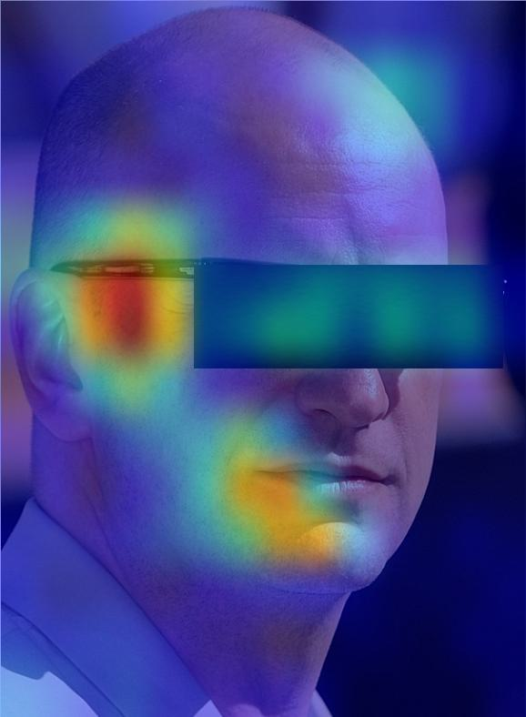

```python
def save_and_display_gradcam(img_path, heatmap, cam_path="cam.jpg", alpha=1):
    # Load the original image
    img = load_img(img_path)
    img = img_to_array(img)

    # Rescale heatmap to a range 0-255
    heatmap = np.uint8(255 * heatmap)

    # Use jet colormap to colorize heatmap
    jet = mpl.colormaps["jet"]

    # Use RGB values of the colormap
    jet_colors = jet(np.arange(256))[:, :3]
    jet_heatmap = jet_colors[heatmap]

    # Create an image with RGB colorized heatmap
    jet_heatmap = array_to_img(jet_heatmap)
    jet_heatmap = jet_heatmap.resize((img.shape[1], img.shape[0]))
    jet_heatmap = img_to_array(jet_heatmap)

    # Superimpose the heatmap on original image
    superimposed_img = jet_heatmap * alpha + img
    superimposed_img = array_to_img(superimposed_img)

    # Save the superimposed image
    superimposed_img.save(cam_path)

    # Display Grad CAM
    display(Image(cam_path))


save_and_display_gradcam(img_path, heatmap_values)
```